# Cryptic Crosswords in R (2022-04-19)

2022-05-06

# TidyTuesday

Join the R4DS Online Learning Community in the weekly #TidyTuesday event! Every week we post a raw dataset, a chart or article related to that dataset, and ask you to explore the data. While the dataset will be “tamed”, it will not always be tidy! As such you might need to apply various R for Data Science techniques to wrangle the data into a true tidy format.

The goal of TidyTuesday is to apply your R skills, get feedback, explore other’s work, and connect with the greater #RStats community! As such we encourage everyone of all skills to participate!

This analysis was done as a follow along with David Robinson’s screencast of Tidy Tuesday (https://youtu.be/T11WKngDEGQ)

# Load the weekly Data

Download the weekly data and make available in the `tt` object.

```r
tuesdata <- tidytuesdayR::tt_load('2022-04-19')
```

```
## --- Compiling #TidyTuesday Information for 2022-04-19 ----
```

```
## --- There are 2 files available ---
```

```
## --- Starting Download ---
```

```
## --- Download complete ---
```

# Readme

Take a look at the readme for the weekly data to get insight on the dataset. This includes a data dictionary, source, and a link to an article on the data.

```r
tuesdata
```

# Glimpse Data

Take an initial look at the format of the data available.

```r
tuesdata %>%
  map(glimpse)
```

```
## Rows: 214,794
## Columns: 9
## $ rowid       <dbl> 293219, 293220, 293221, 293222, 293223, 293224, 293225, 29~
## $ clue        <chr> "Animal doctor tense after sheep rejected (6)", "Minister ~
## $ answer      <chr> "MARMOT", "PRIEST", "EVENS", "STRAPPING", "OUTPLAY", "MALW~
## $ definition  <chr> "Animal", "Minister", "Level", "Robust/binding", "Perform ~
## $ clue_number <chr> "1a", "5a", "10a", "11a", "12a", "13a", "14a", "17a", "18a~
## $ puzzle_date <date> 2021-05-12, 2021-05-12, 2021-05-12, 2021-05-12, 2021-05-1~
## $ puzzle_name <chr> "Daily Telegraph 29673", "Daily Telegraph 29673", "Daily T~
## $ source_url  <chr> "http://bigdave44.com/2021/05/12/dt-29673/", "http://bigda~
## $ source      <chr> "bigdave44", "bigdave44", "bigdave44", "bigdave44", "bigda~
## Rows: 100,661
## Columns: 9
## $ rowid       <dbl> 1, 2, 3, 4, 5, 6, 7, 8, 9, 10, 11, 12, 13, 14, 15, 16, 17,~
## $ clue        <chr> "Acquisitive chap, as we see it (8)", "Back yard fencing w~
## $ answer      <chr> "COVETOUS", "DROOPY", "UNCLOTHING", "EXAM", "KNOCK ON THE ~
## $ definition  <chr> "Acquisitive", "sagging", "Stripping", "where they should ~
## $ clue_number <chr> "1a", "5a", "8a", "9a", "10a", "11a", "13a", "15a", "18a",~
## $ puzzle_date <date> 2019-08-08, 2019-08-08, 2019-08-08, 2019-08-08, 2019-08-0~
## $ puzzle_name <chr> "Times 27424", "Times 27424", "Times 27424", "Times 27424"~
## $ source_url  <chr> "https://times-xwd-times.livejournal.com/2185818.html", "h~
## $ source      <chr> "times_xwd_times", "times_xwd_times", "times_xwd_times", "~
```

```
## $big_dave
## # A tibble: 214,794 x 9
##     rowid clue  answer definition clue_number puzzle_date puzzle_name source_url
##     <dbl> <chr> <chr>  <chr>      <chr>       <date>      <chr>       <chr>
##  1 293219 Anim~ MARMOT Animal     1a          2021-05-12  Daily Tele~ http://bi~
##  2 293220 Mini~ PRIEST Minister   5a          2021-05-12  Daily Tele~ http://bi~
##  3 293221 Leve~ EVENS  Level      10a         2021-05-12  Daily Tele~ http://bi~
##  4 293222 Robu~ STRAP~ Robust/bi~ 11a         2021-05-12  Daily Tele~ http://bi~
##  5 293223 Perf~ OUTPL~ Perform b~ 12a         2021-05-12  Daily Tele~ http://bi~
##  6 293224 Mach~ MALWA~ source of~ 13a         2021-05-12  Daily Tele~ http://bi~
##  7 293225 Drin~ COINT~ Drink      14a         2021-05-12  Daily Tele~ http://bi~
##  8 293226 Boas~ BRAGS  Boasts     17a         2021-05-12  Daily Tele~ http://bi~
##  9 293227 Runs~ CHORE  task       18a         2021-05-12  Daily Tele~ http://bi~
## 10 293228 Spea~ BUTTE~ tree       19a         2021-05-12  Daily Tele~ http://bi~
## # ... with 214,784 more rows, and 1 more variable: source <chr>
##
## $times
## # A tibble: 100,661 x 9
##    rowid clue   answer definition clue_number puzzle_date puzzle_name source_url
##    <dbl> <chr>  <chr>  <chr>      <chr>       <date>      <chr>       <chr>
##  1     1 Acqui~ COVET~ Acquisiti~ 1a          2019-08-08  Times 27424 https://t~
##  2     2 Back ~ DROOPY sagging    5a          2019-08-08  Times 27424 https://t~
##  3     3 Strip~ UNCLO~ Stripping  8a          2019-08-08  Times 27424 https://t~
##  4     4 Witho~ EXAM   where the~ 9a          2019-08-08  Times 27424 https://t~
##  5     5 Put a~ KNOCK~ Put a sto~ 10a         2019-08-08  Times 27424 https://t~
##  6     6 Forei~ EPIST~ letter     11a         2019-08-08  Times 27424 https://t~
##  7     7 Charg~ AGITA~ hurriedly  13a         2019-08-08  Times 27424 https://t~
##  8     8 At fi~ BANAN~ another    15a         2019-08-08  Times 27424 https://t~
##  9     9 Cited~ ADDUC~ Cited      18a         2019-08-08  Times 27424 https://t~
## 10    10 Heady~ TEQUI~ Heady mix~ 21a         2019-08-08  Times 27424 https://t~
## # ... with 100,651 more rows, and 1 more variable: source <chr>
```

# Wrangle

For this analysis we will parse the lengths (word and character) for clues, definitions, and answers.

```r
times <- tuesdata$times
big_dave <- tuesdata$big_dave

# clean data and calculate word lengths
crosswords <- times %>%
  bind_rows(big_dave) %>%
  select(-rowid) %>%
  extract(clue, c("clue", "answer_length"), "(.*) \\((.*)\\)$") %>%
  mutate(year = get_year(puzzle_date),
         month = get_month(puzzle_date),
         month_date = date_group(puzzle_date, "month"),
         definition_idx = str_locate(clue, fixed(definition))[, 1],
         definition_position = case_when(
           definition_idx == 1 ~ 0,
           is.na(definition_idx) ~ NA_real_,
           TRUE ~ 1),
         definition_length = str_length(definition),
         clue_length = str_length(clue),
         n_words_answer = lengths(str_split(answer, " ")),
         n_words_definition = lengths(str_split(definition, " ")),
         n_words_clue = str_count(clue, " ") + 1
         )

crosswords %>%
  select(clue, n_words_clue, answer_length, n_words_answer, answer, n_words_definition, definition) %>%
         head()
```

```
## # A tibble: 6 x 7
##   clue         n_words_clue answer_length n_words_answer answer n_words_definit~
##   <chr>               <dbl> <chr>                  <int> <chr>             <int>
## 1 Acquisitive~            6 8                          1 COVET~                1
## 2 Back yard f~            6 6                          1 DROOPY                1
## 3 Stripping o~            7 10                         1 UNCLO~                1
## 4 Without a m~            8 4                          1 EXAM                  5
## 5 Put a stop ~            8 5,2,3,4                    4 KNOCK~                4
## 6 Foreign let~            8 7                          1 EPIST~                1
## # ... with 1 more variable: definition <chr>
```

# Visualize

Examining the overall data source distribution and looking into missing data

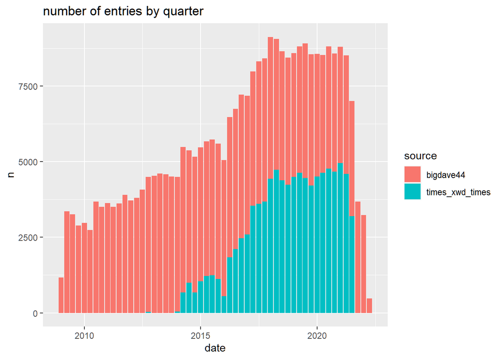

```r
# visualize number of puzzles
crosswords %>%
  mutate(date = date_group(puzzle_date, "month", n = 3)) %>%
  group_by(date) %>%
  count(source) %>%
  ggplot() +
  geom_col() +
  aes(x = date, y = n, fill = source) +
  ggtitle("number of entries by quarter")
```

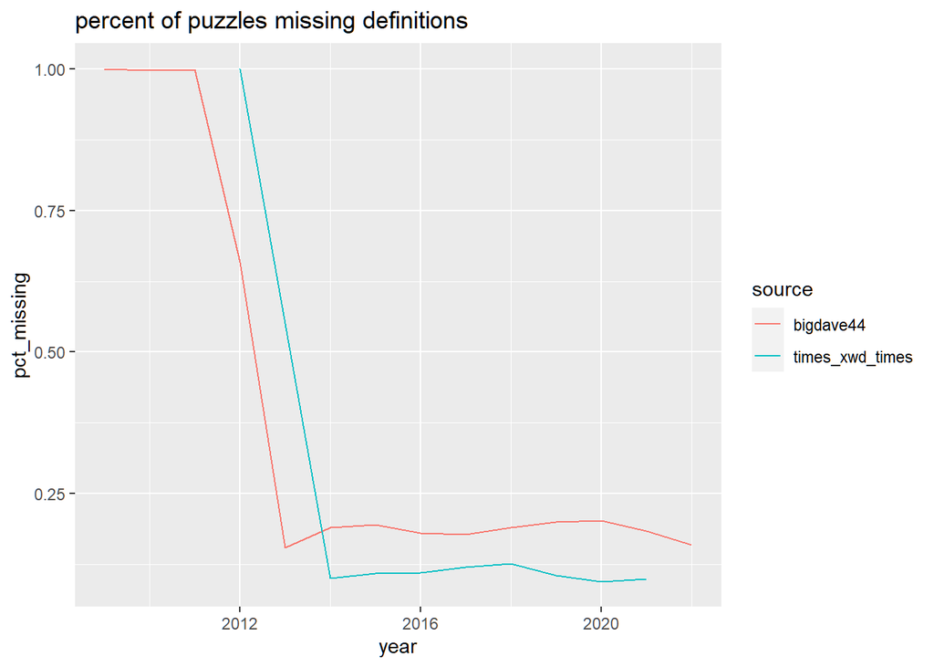

```r
crosswords %>%
  group_by(year, source) %>%
  summarize(pct_missing = mean(is.na(definition_position))) %>%
  ggplot() +
  aes(x = year, y = pct_missing, color = source) +
  geom_line() +
  ggtitle("percent of puzzles missing definitions")
```

More puzzles are provided by “big_dave” and more recent data has less missing data than earlier data.

Where do definitions typically position themselves within clues?

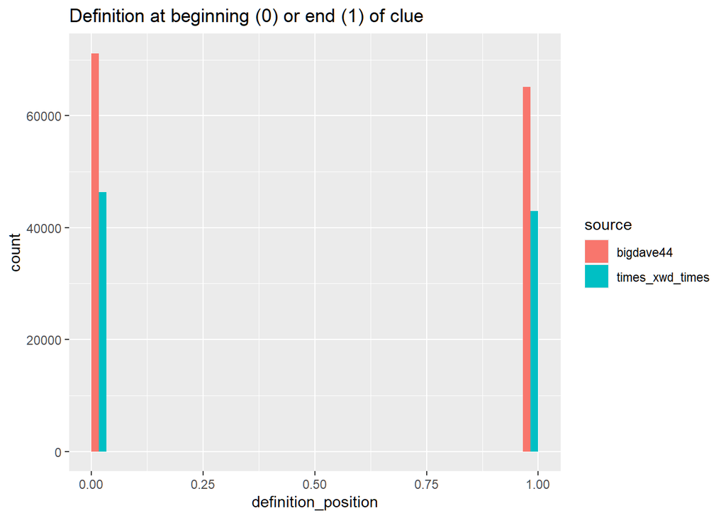

```r
crosswords %>%
  ggplot() +
  aes(x = definition_position, fill = source) +
  geom_histogram(center = 0.5, position = "dodge") +
  ggtitle("Definition at beginning (0) or end (1) of clue")
```

```r
crosswords %>%
  summarize(definition_distribution = mean(definition_position, na.rm = TRUE))
```

```
## # A tibble: 1 x 1
##   definition_distribution
##                     <dbl>
## 1                   0.479
```

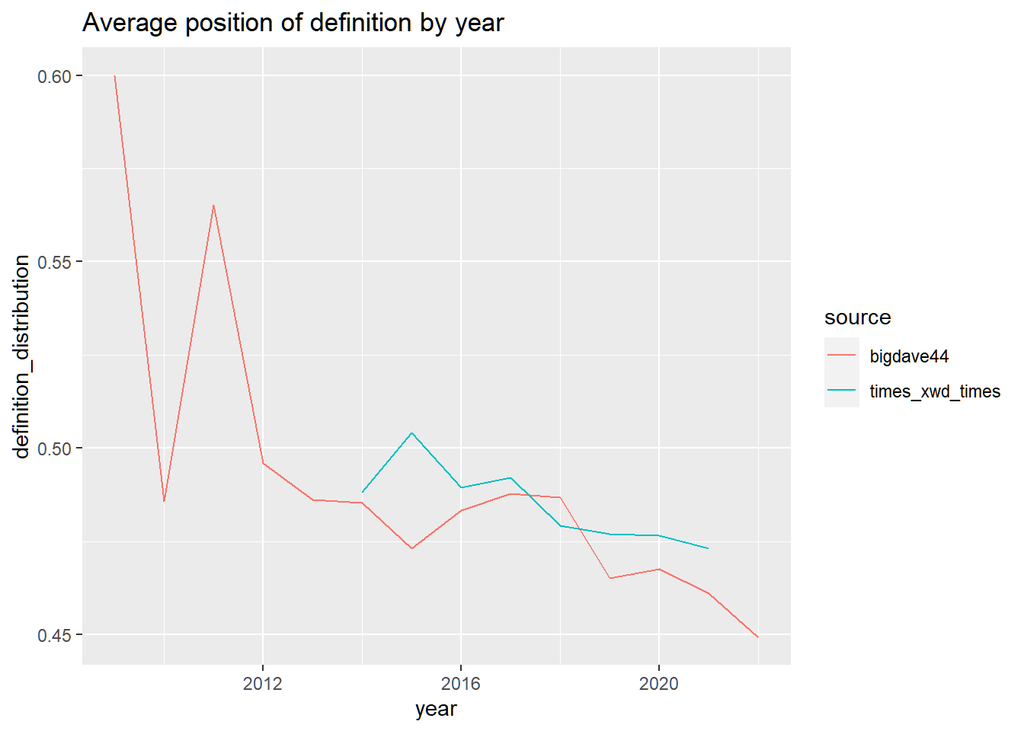

```r
crosswords %>%
  group_by(year, source) %>%
  summarize(definition_distribution = mean(definition_position, na.rm = TRUE)) %>%
  ggplot() +
  geom_line() +
  aes(x = year, y = definition_distribution, color = source) +
  ggtitle("Average position of definition by year")
```

```r
crosswords %>%
  group_by(year, source) %>%
  filter(source == "bigdave44") %>%
  summarize(definition_distribution = mean(definition_position, na.rm = TRUE)) %>%
  glm(definition_distribution ~ year, data = .) %>%
  summary()
```

```
##
## Call:
## glm(formula = definition_distribution ~ year, data = .)
##
## Deviance Residuals:
##       Min         1Q     Median         3Q        Max
## -0.046573  -0.020789   0.001131   0.008484   0.060448
##
## Coefficients:
##              Estimate Std. Error t value Pr(>|t|)
## (Intercept) 15.133880   3.805521   3.977  0.00184 **
## year        -0.007264   0.001888  -3.847  0.00232 **
## ---
## Signif. codes:  0 '***' 0.001 '**' 0.01 '*' 0.05 '.' 0.1 ' ' 1
##
## (Dispersion parameter for gaussian family taken to be 0.0008110402)
##
##     Null deviance: 0.0217382  on 13  degrees of freedom
## Residual deviance: 0.0097325  on 12  degrees of freedom
## AIC: -56.069
##
## Number of Fisher Scoring iterations: 2
```

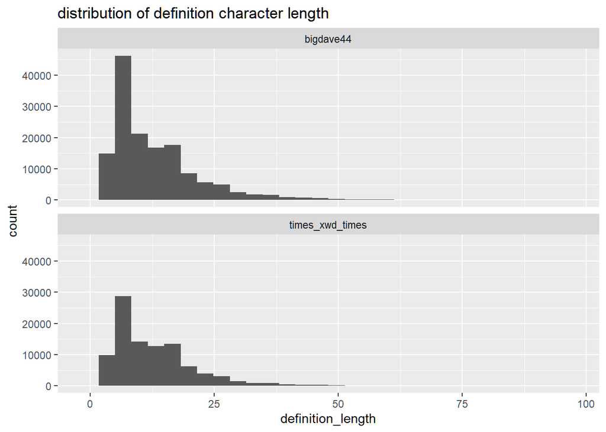

```r
crosswords %>%
  ggplot() +
  geom_histogram() +
  aes(definition_length) +
  facet_wrap(vars(source), nrow = 2) +
  ggtitle("distribution of definition character length")
```

```r
crosswords %>%
  filter(!is.na(definition)) %>%
  group_by(source) %>%
  summarize(median_length = median(definition_length))
```

```
## # A tibble: 2 x 2
##   source          median_length
##   <chr>                   <dbl>
## 1 bigdave44                  10
## 2 times_xwd_times            11
```

Is there a relationship between clue length and definition length?

Is there a relationship with the number of words in the definition and the number of words in the clue?

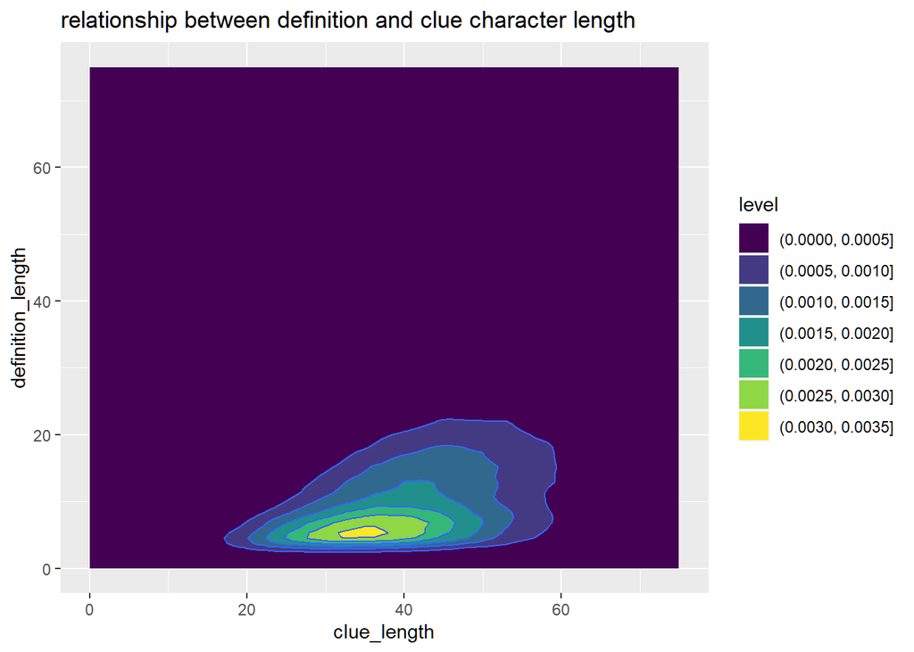

```r
crosswords %>%
  ggplot() +
  aes(x = clue_length, y = definition_length) +
  geom_density_2d_filled() +
  geom_density_2d() +
  scale_x_continuous(limits = c(0, 75)) +
  scale_y_continuous(limits = c(0, 75)) +
  ggtitle("relationship between definition and clue character length")
```

```r
crosswords %>%
  with(cor.test(definition_length, clue_length))
```

```
##
##  Pearson's product-moment correlation
##
## data:  definition_length and clue_length
## t = 146.79, df = 239029, p-value < 2.2e-16
## alternative hypothesis: true correlation is not equal to 0
## 95 percent confidence interval:
##  0.2838750 0.2912298
## sample estimates:
##       cor
## 0.2875567
```

```r
crosswords %>%
  with(cor.test(n_words_definition, n_words_clue))
```

```
##
##  Pearson's product-moment correlation
##
## data:  n_words_definition and n_words_clue
## t = 177.22, df = 310901, p-value < 2.2e-16
## alternative hypothesis: true correlation is not equal to 0
## 95 percent confidence interval:
##  0.2997102 0.3060954
## sample estimates:
##       cor
## 0.3029062
```

```r
crosswords %>%
  with(cor.test(n_words_answer, n_words_definition))
```

```
##
##  Pearson's product-moment correlation
##
## data:  n_words_answer and n_words_definition
## t = 67.08, df = 315453, p-value < 2.2e-16
## alternative hypothesis: true correlation is not equal to 0
## 95 percent confidence interval:
##  0.1151491 0.1220303
## sample estimates:
##       cor
## 0.1185911
```

There is a weak correlation between clue length and definition length, for both characters and word count.

What are the most common words used as answers in cryptic crosswords?

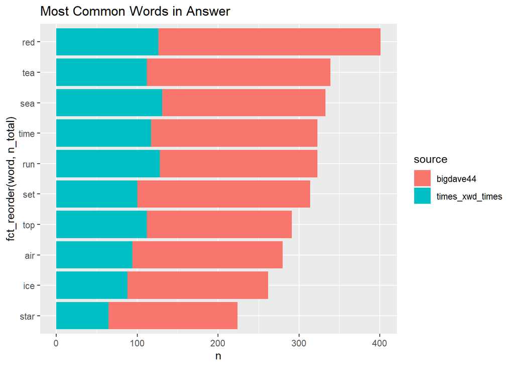

```r
answer_words <- crosswords %>%
  filter(!is.na(answer)) %>%
  unnest_tokens(output=word, input=answer)

answer_words %>%
  count(source, word, sort = TRUE) %>%
  anti_join(stop_words, by = "word") %>%
  group_by(word) %>%
  summarize(source, n, n_total = sum(n)) %>%
  ungroup() %>%
  top_n(20, n_total) %>%
  ggplot() +
  aes(x = n, y = fct_reorder(word, n_total), fill = source) +
  geom_col() +
  ggtitle("Most Common Words in Answer")
```

Are the words used for answers different between sets?

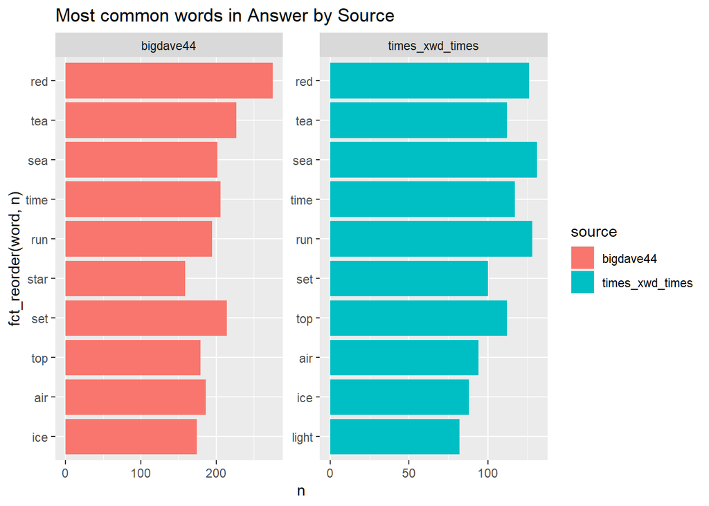

```r
answer_words %>%
  count(source, word, sort = TRUE) %>%
  anti_join(stop_words, by = "word") %>%
  group_by(word) %>%
  summarize(source, n, n_total = sum(n)) %>%
  group_by(source) %>%
  slice_max(n = 10, order_by = n) %>%
  ggplot() +
  aes(x = n, y = fct_reorder(word, n), fill = source) +
  geom_col() +
  facet_wrap(vars(source), scale = "free") +
  ggtitle("Most common words in Answer by Source")
```

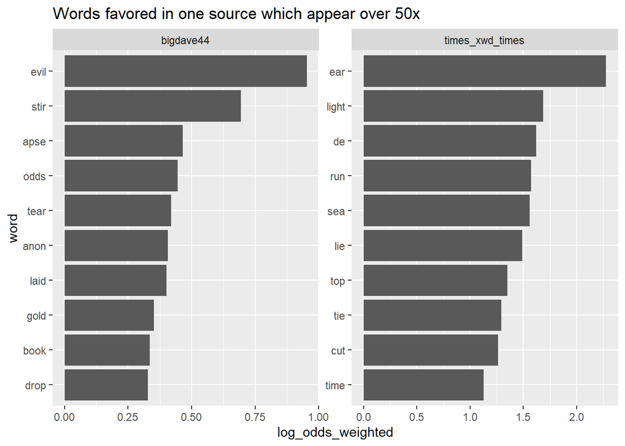

```r
answers_log_odds <- answer_words %>%
  count(source, word) %>%
  anti_join(stop_words, by = "word") %>%
  bind_log_odds(source, word, n)

answers_log_odds %>%
  arrange(desc(abs(log_odds_weighted))) %>%
  group_by(source) %>%
  filter(n > 50) %>%
  top_n(10, log_odds_weighted) %>%
  ungroup() %>%
  mutate(word = fct_reorder(word, log_odds_weighted)) %>%
  ggplot() +
  aes(log_odds_weighted, word) +
  geom_col() +
  facet_wrap(vars(source), scales = "free") +
  ggtitle("Words favored in one source which appear over 50x")
```